# About

# Notes

```python
# Get frequency of each job title
series = pd.Series(title_list).value_counts()
series
```

```
Back-end developer                               53300
Full-stack developer                             44353
Front-end developer                              34822
Mobile developer                                 18804
Desktop or enterprise applications developer     15807
Student                                          15732
Database administrator                           13216
Designer                                         12019
System administrator                             10375
DevOps specialist                                 9549
Data or business analyst                          7559
Data scientist or machine learning specialist     7088
QA or test developer                              6194
Engineering manager                               5256
Embedded applications or devices developer        4819
Game or graphics developer                        4642
Product manager                                   4316
Educator or academic researcher                   3641
C-suite executive (CEO, CTO, etc.)                3491
Marketing or sales professional                   1122
dtype: int64
```

```python
# Modify the 'explode' parameter to highlight the job titles of data science people
explode = np.zeros(len(series))
print('explode=', explode,'\n')
indices = series.index.isin(['Data or business analyst', 'Data scientist or machine learning specialist'])
print('indices=', indices,'\n')
explode[indices] = 0.1
print("modified 'explode'=", explode,'\n')
```

```
explode= [0. 0. 0. 0. 0. 0. 0. 0. 0. 0. 0. 0. 0. 0. 0. 0. 0. 0. 0. 0.]

indices= [False False False False False False False False False False  True  True
 False False False False False False False False]

modified 'explode'= [0.  0.  0.  0.  0.  0.  0.  0.  0.  0.  0.1 0.1 0.  0.  0.  0.  0.  0.
 0.  0. ]
```

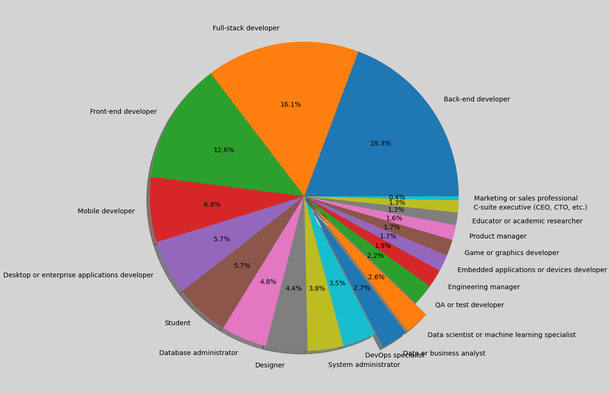

```python
# Plot the pie chart (using the above 'explode')
plt.figure(figsize=(15,15), facecolor='lightgrey');
plt.pie(series, labels = series.index, autopct='%.1f%%',shadow = True, explode = explode, textprops={'fontsize': 14});
plt.show()
```

# Notes

- The proportion of users who are in analytics or ML field are about 5.3%
- Close to 50% of the cohort are web developers

  **code explanation**: We got the frequency of job titles from title_list, by converting it to series and using the pd.value_counts method. Using these frequency counts, we made a pie chart. To pop the two specific job titles, we got a boolean array of series where the value is equal to the specific job title. We used this boolean array to index an array of zeros and replace the values in the array with a non-zero number

# Let's look only at analysts : Plot the age groups of analysts

```python
# Boolean array of analysts
df.DevType.isin(['Data or business analyst', 'Data scientist or machine learning specialist'])
```

```
0        False
1        False
2        False
3        False
4        False
         ...
98850    False
98851    False
98852    False
98853    False
98854    False
Name: DevType, Length: 98855, dtype: bool
```

```python
# Filter out the analysts from the main df
analysts = df.loc[df.DevType.isin(['Data or business analyst', 'Data scientist or machine learning specialist']), :]
analysts.head(10)
```

|  | Respondent | Hobby | OpenSource | Country | Student | Employment | FormalEducation | UndergradMajor | CompanySize | DevType | ... | Exercise | Gender | SexualOrientation | EducationParents | RaceEthnicity | Age | Dependents | MilitaryUS | SurveyTooLong | SurveyEasy |
| --- | --- | --- | --- | --- | --- | --- | --- | --- | --- | --- | --- | --- | --- | --- | --- | --- | --- | --- | --- | --- | --- |
| 88 | 132 | Yes | No | Finland | No | Employed full-time | Master’s degree (MA, MS, M.Eng., MBA, etc.) | A natural science (ex. biology, chemistry, phy... | 500 to 999 employees | Data scientist or machine learning specialist | ... | NaN | NaN | NaN | NaN | NaN | NaN | NaN | NaN | NaN | NaN |
| 112 | 162 | Yes | No | India | No | Employed full-time | Bachelor’s degree (BA, BS, B.Eng., etc.) | Computer science, computer engineering, or sof... | 5,000 to 9,999 employees | Data or business analyst | ... | 1 - 2 times per week | Male | Straight or heterosexual | Bachelor’s degree (BA, BS, B.Eng., etc.) | South Asian | 18 - 24 years old | No | NaN | The survey was too long | Somewhat easy |
| 126 | 187 | Yes | No | Italy | No | Employed full-time | Bachelor’s degree (BA, BS, B.Eng., etc.) | Computer science, computer engineering, or sof... | 100 to 499 employees | Data scientist or machine learning specialist | ... | I don't typically exercise | Male | Straight or heterosexual | Master’s degree (MA, MS, M.Eng., MBA, etc.) | White or of European descent | 25 - 34 years old | No | NaN | The survey was an appropriate length | Neither easy nor difficult |
| 148 | 230 | Yes | Yes | United States | No | Employed full-time | Bachelor’s degree (BA, BS, B.Eng., etc.) | Mathematics or statistics | 1,000 to 4,999 employees | Data scientist or machine learning specialist | ... | NaN | NaN | NaN | NaN | NaN | NaN | NaN | NaN | NaN | NaN |
| 223 | 334 | Yes | Yes | Denmark | Yes, full-time | Employed part-time | Secondary school (e.g. American high school, G... | NaN | 20 to 99 employees | Data scientist or machine learning specialist | ... | NaN | NaN | NaN | NaN | NaN | NaN | NaN | NaN | NaN | NaN |
| 347 | 502 | No | No | United States | No | Employed full-time | Other doctoral degree (Ph.D, Ed.D., etc.) | A natural science (ex. biology, chemistry, phy... | 100 to 499 employees | Data scientist or machine learning specialist | ... | I don't typically exercise | Female | Straight or heterosexual | Bachelor’s degree (BA, BS, B.Eng., etc.) | White or of European descent | 35 - 44 years old | Yes | No | The survey was an appropriate length | Somewhat difficult |
| 393 | 563 | No | No | France | No | Employed full-time | Other doctoral degree (Ph.D, Ed.D., etc.) | A natural science (ex. biology, chemistry, phy... | 20 to 99 employees | Data scientist or machine learning specialist | ... | 3 - 4 times per week | Male | Straight or heterosexual | Bachelor’s degree (BA, BS, B.Eng., etc.) | Middle Eastern | 25 - 34 years old | No | NaN | The survey was an appropriate length | Somewhat easy |
| 576 | 804 | Yes | No | France | No | Employed full-time | Master’s degree (MA, MS, M.Eng., MBA, etc.) | Mathematics or statistics | 20 to 99 employees | Data scientist or machine learning specialist | ... | 1 - 2 times per week | Male | Straight or heterosexual | Some college/university study without earning ... | White or of European descent | 18 - 24 years old | No | NaN | The survey was an appropriate length | Somewhat easy |
| 618 | 862 | Yes | Yes | United States | Yes, full-time | Employed part-time | Some college/university study without earning ... | NaN | 10 to 19 employees | Data or business analyst | ... | 3 - 4 times per week | Male | Straight or heterosexual | Some college/university study without earning ... | White or of European descent | 18 - 24 years old | No | No | The survey was too long | Somewhat easy |
| 666 | 935 | No | No | France | Yes, full-time | Employed full-time | Master’s degree (MA, MS, M.Eng., MBA, etc.) | Information systems, information technology, o... | 10,000 or more employees | Data or business analyst | ... | NaN | NaN | NaN | NaN | NaN | NaN | NaN | NaN | NaN | NaN |

10 rows × 129 columns

```python
analysts.shape
```

```
(1368, 129)
```

```python
# Look at the `Age` col of the `analyts` df
analysts.Age.value_counts()
```

```
25 - 34 years old     519
18 - 24 years old     171
35 - 44 years old     154
45 - 54 years old      41
55 - 64 years old      20
65 years or older       4
Under 18 years old      4
Name: Age, dtype: int64
```

```python
# Get the frequency of each age group
analysts.Age.value_counts()
```

```
25 - 34 years old     519
18 - 24 years old     171
35 - 44 years old     154
45 - 54 years old      41
55 - 64 years old      20
65 years or older       4
Under 18 years old      4
Name: Age, dtype: int64
```

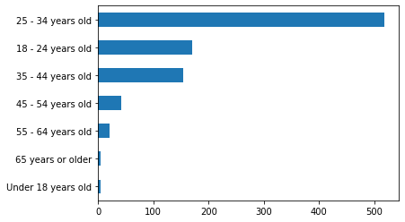

```python
# Plot
analysts.Age.value_counts().plot.barh().invert_yaxis()
```

# Notes

- A significant majority of the data science professionals are of the age group 25-34

Plot the satisfaction level of each age group in the above

```python
# Satisfaction level for each age group
pd.crosstab(analysts.JobSatisfaction, analysts.Age)
```

| Age JobSatisfaction | 18 - 24 years old | 25 - 34 years old | 35 - 44 years old | 45 - 54 years old | 55 - 64 years old | 65 years or older | Under 18 years old |
| --- | --- | --- | --- | --- | --- | --- | --- |
| Extremely dissatisfied | 1 | 13 | 9 | 3 | 0 | 0 | 0 |
| Extremely satisfied | 38 | 105 | 36 | 6 | 3 | 0 | 0 |
| Moderately dissatisfied | 8 | 51 | 19 | 5 | 1 | 0 | 0 |
| Moderately satisfied | 67 | 178 | 50 | 13 | 6 | 2 | 0 |
| Neither satisfied nor dissatisfied | 7 | 37 | 9 | 4 | 2 | 0 | 1 |
| Slightly dissatisfied | 14 | 49 | 12 | 3 | 6 | 0 | 0 |
| Slightly satisfied | 22 | 69 | 13 | 6 | 0 | 0 | 0 |

```python
# Satisfaction level for each age group with normalized values
pd.crosstab(analysts.JobSatisfaction, analysts.Age, normalize = 'columns')
```

| Age JobSatisfaction | 18 - 24 years old | 25 - 34 years old | 35 - 44 years old | 45 - 54 years old | 55 - 64 years old | 65 years or older | Under 18 years old |
| --- | --- | --- | --- | --- | --- | --- | --- |
| Extremely dissatisfied | 0.006369 | 0.025896 | 0.060811 | 0.075 | 0.000000 | 0.0 | 0.0 |
| Extremely satisfied | 0.242038 | 0.209163 | 0.243243 | 0.150 | 0.166667 | 0.0 | 0.0 |
| Moderately dissatisfied | 0.050955 | 0.101594 | 0.128378 | 0.125 | 0.055556 | 0.0 | 0.0 |
| Moderately satisfied | 0.426752 | 0.354582 | 0.337838 | 0.325 | 0.333333 | 1.0 | 0.0 |
| Neither satisfied nor dissatisfied | 0.044586 | 0.073705 | 0.060811 | 0.100 | 0.111111 | 0.0 | 1.0 |
| Slightly dissatisfied | 0.089172 | 0.097610 | 0.081081 | 0.075 | 0.333333 | 0.0 | 0.0 |
| Slightly satisfied | 0.140127 | 0.137450 | 0.087838 | 0.150 | 0.000000 | 0.0 | 0.0 |

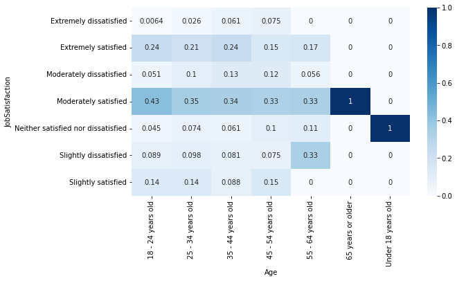

```python
# Plot
plt.figure(figsize=(9,5))
sns.heatmap(pd.crosstab(analysts.JobSatisfaction, analysts.Age, normalize = 'columns'), cmap = 'Blues', annot = True)
plt.show()
```

# Notes

# Monthly salaries of the analysts

```python
# Filter out the relevant salary cols from the df
salaries = analysts.loc[:,['Salary', 'SalaryType', 'Currency', 'ConvertedSalary']].dropna()
# Remove the commas from the 'Salary' col
salaries['Salary'] = salaries.Salary.apply(lambda x: x.replace(',', '')).apply(float)
salaries.head(10)
```

|  | Salary | SalaryType | Currency | ConvertedSalary |
| --- | --- | --- | --- | --- |
| 347 | 113000.0 | Yearly | U.S. dollars ($) | 113000.0 |
| 393 | 2500.0 | Monthly | Euros (€) | 36720.0 |
| 576 | 34000.0 | Yearly | Euros (€) | 41612.0 |
| 618 | 30000.0 | Yearly | U.S. dollars ($) | 30000.0 |
| 802 | 300000.0 | Yearly | U.S. dollars ($) | 300000.0 |
| 805 | 72000.0 | Monthly | Euros (€) | 1000000.0 |
| 823 | 33000.0 | Yearly | Euros (€) | 40388.0 |
| 912 | 52000.0 | Yearly | U.S. dollars ($) | 52000.0 |
| 1104 | 5500.0 | Monthly | Swiss francs | 68820.0 |
| 1316 | 65000.0 | Yearly | U.S. dollars ($) | 65000.0 |

```python
# Frequency of different salary types
salaries.SalaryType.value_counts()
```

```
Yearly     378
Monthly    179
Weekly      18
Name: SalaryType, dtype: int64
```

```python
# Convert all salaries to monthly salary
# Firstly add a new col
salaries['monthly_salary'] = salaries.ConvertedSalary
# Then convert the yearly and weekly ones to monthly scale
for i in salaries.index:
    if salaries.loc[i, 'SalaryType'] == 'Yearly':
        salaries.loc[i, 'monthly_salary'] = salaries.loc[i, 'ConvertedSalary']/12
    elif salaries.loc[i, 'SalaryType'] == 'Weekly':
        salaries.loc[i, 'monthly_salary'] = salaries.loc[i, 'ConvertedSalary']*4
```

```python
salaries.head()
```

|  | Salary | SalaryType | Currency | ConvertedSalary | monthly_salary |
| --- | --- | --- | --- | --- | --- |
| 347 | 113000.0 | Yearly | U.S. dollars ($) | 113000.0 | 9416.666667 |
| 393 | 2500.0 | Monthly | Euros (€) | 36720.0 | 36720.000000 |
| 576 | 34000.0 | Yearly | Euros (€) | 41612.0 | 3467.666667 |
| 618 | 30000.0 | Yearly | U.S. dollars ($) | 30000.0 | 2500.000000 |
| 802 | 300000.0 | Yearly | U.S. dollars ($) | 300000.0 | 25000.000000 |

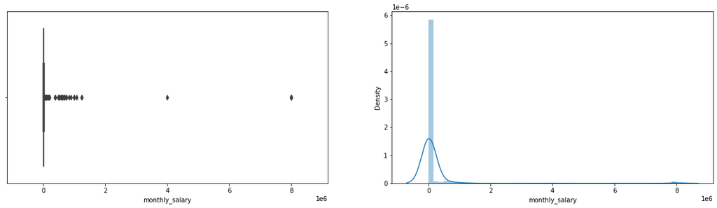

```python
# Plot
fig, ax = plt.subplots(1,2, sharex = True)
fig.set_figheight(5)
fig.set_figwidth(20)
sns.boxplot(salaries.monthly_salary, ax= ax[0])
sns.distplot(salaries.monthly_salary, ax = ax[1])
plt.show()
```

# Notes

- Histogram in this case does not give much information because of the extreme skew in the distribution
- The data is highly skewed. Hence, we will look at the numbers

# Look at the salary numbers

```python
salaries.monthly_salary.describe().apply(lambda x: format(x, '.2f'))
```

```
count        575.00
mean      135512.06
std       838091.65
min            0.00
25%         4718.96
50%         7750.00
75%        19140.00
max      8000000.00
Name: monthly_salary, dtype: object
```

# Notes

- 75% of the people have salaries less than 19140 USD and the median salary for a data scientist is 7750 USD

# Indian salaries

```python
# Boolean array of Salaries in Indian currency
salaries.Currency.apply(lambda x: 'Indian' in x)
```

```
347      False
393      False
576      False
618      False
802      False
         ...
82963     True
84404    False
84486    False
86584    False
86871    False
Name: Currency, Length: 575, dtype: bool
```

```python
# Select the salaries in Indian currency, from the df
Indian_salaries = salaries.loc[salaries.Currency.apply(lambda x: 'Indian' in x), :]
```

```python
# Get all kinds of salaries into monthly format
Indian_salaries['monthly_salary'] = Indian_salaries.Salary
for i in Indian_salaries.index:
    if Indian_salaries.loc[i, 'SalaryType'] == 'Yearly':
        Indian_salaries.loc[i, 'monthly_salary'] = Indian_salaries.loc[i, 'Salary']/12
    elif Indian_salaries.loc[i, 'SalaryType'] == 'Weekly':
        Indian_salaries.loc[i, 'monthly_salary'] = Indian_salaries.loc[i, 'Salary']*4
```

```python
# top 5 monthly Indian salaries
pd.set_option('display.float_format', lambda x: '%.3f' % x)
Indian_salaries.sort_values(by='monthly_salary', ascending=False).head(20)
```

|  | Salary | SalaryType | Currency | ConvertedSalary | monthly_salary |
| --- | --- | --- | --- | --- | --- |
| 68120 | 2000000.000 | Monthly | Indian rupees (₹) | 375708.000 | 2000000.000 |
| 8478 | 950000.000 | Monthly | Indian rupees (₹) | 178464.000 | 950000.000 |
| 65481 | 950000.000 | Monthly | Indian rupees (₹) | 178464.000 | 950000.000 |
| 28879 | 785600.000 | Monthly | Indian rupees (₹) | 147576.000 | 785600.000 |
| 29439 | 7000000.000 | Yearly | Indian rupees (₹) | 109581.000 | 583333.333 |
| 20521 | 2500000.000 | Yearly | Indian rupees (₹) | 39136.000 | 208333.333 |
| 7279 | 2500000.000 | Yearly | Indian rupees (₹) | 39136.000 | 208333.333 |
| 58778 | 2500000.000 | Yearly | Indian rupees (₹) | 39136.000 | 208333.333 |
| 41306 | 2100000.000 | Yearly | Indian rupees (₹) | 32874.000 | 175000.000 |
| 77230 | 135000.000 | Monthly | Indian rupees (₹) | 25356.000 | 135000.000 |
| 4678 | 125000.000 | Monthly | Indian rupees (₹) | 23484.000 | 125000.000 |
| 3963 | 1400000.000 | Yearly | Indian rupees (₹) | 21916.000 | 116666.667 |
| 10212 | 1243000.000 | Yearly | Indian rupees (₹) | 19458.000 | 103583.333 |
| 82963 | 1200000.000 | Yearly | Indian rupees (₹) | 18785.000 | 100000.000 |
| 7703 | 100000.000 | Monthly | Indian rupees (₹) | 18780.000 | 100000.000 |
| 59718 | 1100000.000 | Yearly | Indian rupees (₹) | 17220.000 | 91666.667 |
| 53353 | 90000.000 | Monthly | Indian rupees (₹) | 16908.000 | 90000.000 |
| 50625 | 1000000.000 | Yearly | Indian rupees (₹) | 15654.000 | 83333.333 |
| 29697 | 900000.000 | Yearly | Indian rupees (₹) | 14089.000 | 75000.000 |
| 68768 | 800000.000 | Yearly | Indian rupees (₹) | 12524.000 | 66666.667 |

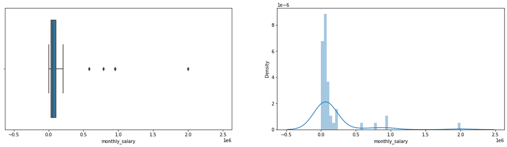

```python
# Plot
fig, ax = plt.subplots(1,2, sharex = True)
fig.set_figheight(5)
fig.set_figwidth(20)
sns.boxplot(Indian_salaries.monthly_salary, ax= ax[0])
sns.distplot(Indian_salaries.monthly_salary, ax = ax[1])
plt.show()
```

# Look at the salary numbers

```python
Indian_salaries.monthly_salary.describe().apply(lambda x: format(x, '.0f'))
```

```
count         48
mean      170981
std       347704
min            0
25%        35000
50%        58333
75%       106854
max      2000000
Name: monthly_salary, dtype: object
```

# Notes

# Conclusion:

Now that we got a good idea of how to plot, manipulate, draw insights and extract relevant data from a huge dataset, and we still have a lot of unexplored columns in the dataset!

All the best!